**Dragos Ailoae**

Applied Statistics and Econometrics I

2021-10-12

# Practice problems

**Concepts: Expected value operator. linear transformations of RVs**

1) Prove

a. $E[a+bx]=a +b E[x]$ while $Var[a+bx]=b^2 Var[x]$

b. $Var[x]\equiv \sigma_{x}^{2}=E[x^2]-\mu_{x}^2$

c. $Cov[x,y] \equiv \sigma_{x,y} = E[xy]- \mu_x \mu_y$

d. If $X \sim N(\mu,\sigma)$ then transformed variable $Z=\frac{X-\mu}{\sigma}$ is distributed as $Z\sim N(0,1)$

**Concepts: Linear regression model, CLRM assumptions, properties of OLS estimator under CLRM assumptions**

2) Under CLRM assumptions prove that:

a. The OLS estimator is unbiased.

b. The OLS estimator variance is $\operatorname{Var}[\mathbf{b} \mid \mathbf{X}] = \sigma^2(X'X)^{-1}$.

c. An unbiased estimator of $\sigma^{2}$ is $s^{2}=\frac{\mathbf{e}^{\prime} \mathbf{e}}{n-K}$

d. The standard error of parameter $b_k$ is $SE[b_k]=\left\{\left[s^{2}\left(\mathbf{X}^{\prime} \mathbf{X}\right)^{-1}\right]_{k k}\right\}^{1 / 2}$

**Concepts: Sampling, CLT**

3) Achievement test scores of all high school seniors in a state have mean 60 and variance 64. A random sample of $n=100$ students from one large high school had a mean score of 58 . Is there evidence to suggest that this high school is inferior? **Hint**: calculate the probability that the sample mean is at most 58 when n=100. Potentially useful statistical tables https://ciresar.github.io/NYU/Lab_3/StatsTables.pdf

**Concepts: Bivariate distribution (discrete RVs), conditional distribution, marginal distribution**

4) Given the following joint probability distribution,

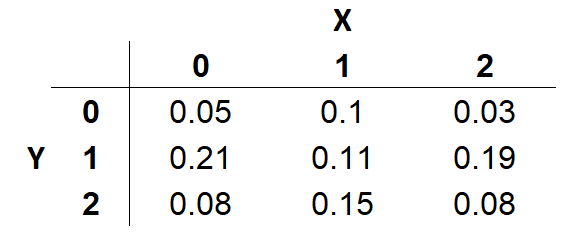

a. Compute the following probabilities: $\operatorname{Prob}[Y<2], \operatorname{Prob} [Y<2, X>0], \operatorname{Prob}[Y=1, X \geq 1]$.

b. Find the marginal distributions of $X$ and $Y$.

c. Calculate $E[X], E[Y], \operatorname{Var}[X], \operatorname{Var}[Y], \operatorname{Cov}[X, Y]$, and $E\left[X^{2} Y^{3}\right]$.

d. Calculate $\operatorname{Cov}\left[\mathrm{Y}, \mathrm{X}^{2}\right]$.

e. What are the conditional distributions of $Y$ given $X=2$ and of $X$ given $Y>0$ ?

f. Find $E[Y \mid X]$ and $\operatorname{Var}[Y \mid X]$. Obtain the two parts of the variance decomposition $\operatorname{Var}[Y]=E_{x}[\operatorname{Var}[Y \mid X]]+\operatorname{Var}_{x}[E[Y \mid X]]$

**Concept: Bivariate distribution (continuous RVs)**

5) Let the joint density of two random variables $x_{1}$ and $x_{2}$ be given by $$ f\left(x_{1}, x_{2}\right)= \begin{cases}\frac{1}{6} X_{1}, \quad \text { if } \quad 0 \leq x_{1} \leq 2, \quad 0 \leq x_{2} \leq 3 \\ 0, \quad \text { otherwise }\end{cases} $$ Find $\operatorname{Cov}[x_{1}, x_{2}]$

**Concept: Univariate regression, goodness of fit, R-squared**

6) For the regression model $Y=\beta_{0}+\beta_{1} X+\varepsilon$ find the OLS estimators $\hat\beta_0$,$\hat\beta_1$ and the coefficient of determination (R-squared) given the following data: \begin{array}{rc} \mathrm{Y}_{\mathrm{i}} & \mathrm{X}_{\mathrm{i}} \\ 4 & 1 \\ 5 & 4 \\ 7 & 5 \\ 12 & 6 \end{array}